# Tarea 1: Exploración y Visualización de Datos

Felipe Bravo, Bárbara Poblete, Hernan Sarmiento, Aymé Arango, Alison Fernandez, Ignacio Meza, Cinthia Mabel Sanchez, Gabriel Ramos

Marzo 2021

# 1 Declaración de compromiso ético

Nosotros **Javier Lavados Jillbert y Nicolás García Ríos**, declaramos que realizamos de manera grupal los pasos de la presente actividad. También declaramos no incurrir en copia, ni compartir nuestras respuestas con otras personas ni con otros grupos. Por lo que, ratificamos que las respuestas son de nuestra propia confección y reflejan nuestro propio conocimiento.

# 2 Instrucciones

1. Trabajen en equipos de dos personas. Salvo excepciones, no se corregirá entregas con menos de dos integrantes.
2. Modifique este archivo `.Rmd` agregando sus respuestas donde corresponda.
3. Para cada pregunta, cuando corresponda, **incluya el código fuente que utilizó para llegar a su respuesta**.
4. El formato de entrega para esta actividad es un archivo html. **Genere un archivo HTML usando RStudio** y súbalo a U-Cursos. Basta con que uno de los integrantes haga la entrega. Si ambos hacen una entrega en U-Cursos, se revisará cualquiera de éstas.

# 3 Tarea

La primera parte de esta actividad son preguntas teóricas que avanzaron en las clases del curso de Minería de datos.

## 3.1 Teoría

*1. ¿Cuál es el objetivo de Minería de datos y qué la diferencia de Machine Learning? De un ejemplo para explicar la diferencia.*

**Respuesta:** La minería de datos une ideas de distintas áreas de la computación con el fin de generar nuevo entendimiento. En cambio El aprendizaje de máquinas genera predicciones de comportamiento, patrones, etc.

Ejemplo: Tomemos el caso de Alexa, una asistente virtual. Imaginemos que un cliente le da instrucciones a Alexa por medio de la voz. El Machine Learning, en base a las señales del reconocimiento de voz, predice cuál es la instrucción a la que se refiere el cliente, ya sea poner una canción en youtube, o buscar una dirección en Google Maps. Por otro lado, La Minería de Datos entendería que el cliente suele escuchar algún género de música en específico debido a sus solicitudes, o que la mayoría de clientes son personas jóvenes que adultos mayores debido a la tecnología.

*2. Describa y compare los siguientes métodos usados en Minería de datos: clasificación vs. clustering.*

**Respuesta:** **Clasificación -** Este es un método predictivo el cuál se basa en tener un set de entrenamiento que entrena modelos, y que permitan predecir la clase de futuros datos desconocidos.

**Clustering -** Este es un método descriptivo el cuál se basa en tener un conjunto de datos (puntos) con atributos, y que busca agrupar los datos más similares entre sí en llamados clusters.

- Ambos son métodos usados en Minería de Datos.
- El método de Clasificación es un método predictivo, mientras que el de Clustering es un método descriptivo.
- El método de Clasificación permite predecir una clase en base a los atributos de un elemento. Por otro lado, el método de Clustering agrupa tipos datos en grupos en base a sus atributos.

*3. ¿Qué desafios existen en Minería de datos?*

*4. Respecto a los tipos de atributo, ¿cuál es la diferencia entre razón e intervalo? De un ejemplo.*

**Respuesta:** La razón tiene un cero definido o absoluto, mientras que los datos intervalo no lo tienen. Por ejemplo, Kelvin y °C, ya que Kelvin su cero absoluto definido y los grados celcius no.

*5. ¿Qué factores que ocasionan errores en el análisis de datos deben ser considerados para la limpieza de un set de datos?*

**Respuesta:** La existencia de ruido, datos inexistentes, datos duplicados y datos inconsistentes.

*6. ¿Qué es el análisis exploratorio de datos o EDA?*

**Respuesta:** Es una forma de análisis de datos, que engloba un conjunto de técnicas para poder comprender de manera rápida la naturaleza de una colección de datos o dataset. Este se basa principalemnte en dos criterios, las estadíasticas de resumen y la visualización de datos.

*7. Describa las medidas de tendencia central: media y mediana. Exponga la diferencia entre ambas.*

**Respuesta:** Las medidas de tendencia central son medidas que tratan de resumir los valores observados en un único valor asociado al centro de la muestra: - la media o promedio es el valor que en promedio generan los datos. Debido a que depende aritméticamente de los valores de los datos, es muy sensible a outliers. - Por otro lado, la mediana es el valor central de la muestra respecto a la cantidad de elementos del dataset. Debido a que depende de la cantidad de elementos y no de los valores de estos, esta medida es más robusta a outliers.

*8. ¿Qué es una matriz de correlación y para qué sirve?*

**Respuesta:** Una matriz de correlación es una tabla que grafica las dimensiones de un dataset en ambos ejes con sus coeficientes de correlación respectivos, donde el coeficiente de correlación indica la dependencia lineal entre los valores de dos variables (en este caso, dos dimensines de un dataset). Esta matriz sirve para visualizar las dependencias lineales de los valores de distintas dimensiones sin tener que graficarlas una a una.

*9. Explique cómo se identifican los valores atípicos u outliers en un boxplot.*

**Respuesta:** Los boxplots son diagramas de caja que se construyen a partir de los cuartiles de la muestra, donde la caja central representa el 50% de los datos, mientras que la caja más extrema representan los valores más extremos respecto a la distancia que hay entre el primer y tercer cuartil. Dado que la caja más externa ya representan los valores más extremos de la muestra (el 25% inferior y el 25% superior aproximadamente), todos los valores que salgan de la caja externa serán identificados como valores atípicos o los llamados outliers.

## 3.2 Práctica

En esta parte de la actividad se trabajará con los datos del Proceso Constituyente 2016-2017 publicados en el Portal de Datos Abiertos del Gobierno de Chile, para mayor información pueden ingresar al siguiente link: https://datos.gob.cl/dataset/proceso-constituyente-abierto-a-la-ciudadania. Los datos corresponden a las actas de los Encuentros Locales Autoconvocados (ELAs), en cada cual, un grupo de personas se reune a discutir distintos conceptos como por ejemplo: salud, educación, seguridad, etc.

Los datos con los que trabajarán consisten en la cantidad de veces que cada concepto constitucional fue mencionado por cada localidad de Chile.

Para cargar los datos, use:

```r
data_tf <- read.csv("http://dcc.uchile.cl/~hsarmien/mineria/datasets/actas.txt", header = T)
```

**Por cada pregunta adjunte el código R que utilizó para llegar a la respuesta. Respuestas sin código no recibirán puntaje**

### 3.2.1 Exploración básica

1. ¿Cuáles son las dimensiones del dataset (filas, columnas)? Adjunte código o indique cómo determinó la cantidad de datos total.

```r
dim(data_tf)
```

```
## [1] 328 113
```

2. ¿Qué describe cada línea del dataset? (ejemplifique tomando la fila 12)

```r
data_tf[12,]
```

```
##                         localidad a_huelga a_la_educacion a_la_honra._al_honor
## 12 Antofagasta/Antofagasta/Taltal        0              2                    0
##    a_la_identidad_cultural a_la_informacion a_la_integracion_de_discapacidad
## 12                       0                0                                0
##    a_la_integridad_fisica_y_psiquica a_la_nacionalidad a_la_participacion
## 12                                 0                 0                  0
##    a_la_salud a_la_seguridad.vida_sin_violencia a_la_seguridad_social a_la_vida
## 12          2                                 2                     0         0
##    a_la_vivienda_digna a_sindicalizarse_y_a_la_negociacion_colectiva
## 12                   1                                             0
##    a_sufragio.votar acceso_a_informacion_publica acceso_a_la_cultura
## 12                0                            0                   0
##    al_salario_equitativo al_trabajo amistad_civica autonomia.libertad
## 12                     2          0              0                  0
##    bien_comun.comunidad cambio_o_reforma_constitucional ciudadania
## 12                    0                               0          0
##    congreso_o_parlamento_.estructura_y_funciones.
## 12                                              0
##    contraloria_general.tribunales_de_cuentas cumplimiento_de_las_leyes_y_normas
## 12                                         2                                  2
##    cumplimiento_de_obligaciones_fiscales
## 12                                     1
##    cumplimiento_de_tratados_y_obligaciones_internacionales
## 12                                                       0
##    de_los_pueblos_indigenas de_peticion_ante_las_autoridades de_propiedad
## 12                        0                                0            0
##    de_proteccion_y_conservacion_de_patrimonio_historico_y_cultural
## 12                                                               1
##    de_satisfacer_cargas_publicas
## 12                             0
##    deberes_de_proteccion_de_conservacion_de_la_naturaleza
## 12                                                      2
##    defensor_del_pueblo.ciudadano democracia derecho_de_asociacion
## 12                             0          0                     0
##    derechos_del_nino._nina_y_adolescente desarrollo descentralizacion dignidad
## 12                                     0          0                 2        0
##    diversidad division_territorial
## 12          0                    0
##    ejercicio_legitimo_y_no_abusivo_de_los_derechos emprendimiento_libre
## 12                                               1                    0
```

[output cut: 33 more lines]

```
## 12                      0        1                                   1
##    proteccion._promocion_y_respeto_de_los_derechos_humanos_y_fundamentales
## 12                                                                       2
##    republica respeto respeto.conservacion_de_la_naturaleza_o_medio_ambiente
## 12         0       2                                                      1
##    respeto_a_la_naturaleza.medio_ambiente respeto_de_derechos_de_otros
## 12                                      1                            2
##    respeto_por_la_constitucion responsabilidad reunion_pacifica
## 12                           0               2                0
##    regimen_de_gobierno_presidencial.semi.presidencial.parlamentario seguridad
## 12                                                                0         2
##    ser_elegido_en_cargos_publicos servicio_a_la_comunidad soberania solidaridad
## 12                              0                       1         0           1
##    subsidiaridad tolerancia transparencia_y_publicidad unidad
## 12             0          1                          0      0
```

3. ¿Existen localidades repetidas en el dataset? Adjunte el código o indique cómo llegó a esa conclusión.

```r
nrow(data_tf)   # Entrega la cantidad de localidades en la tabla original
```

```
## [1] 328
```

```r
length(unique(data_tf$localidad))   # Entrega la cantidad de localidades en la tabla sin repeticiones de filas
```

```
## [1] 328
```

```r
# Como ambos números son iguales, tenemos que no se repiten localidades
```

4. Liste los nombres de las columnas del dataset `data_tf`. Adjunte código en R y *recuerde* usar `head` si el resultado es muy largo.

```r
columns = names(data_tf)
head(columns)
```

```
## [1] "localidad"               "a_huelga"
## [3] "a_la_educacion"          "a_la_honra._al_honor"
## [5] "a_la_identidad_cultural" "a_la_informacion"
```

### 3.2.2 Análisis

1. Liste todas las localidades donde *no* se discutió el concepto `igualdad`.

```r
data_tf[data_tf$igualdad==0,c("localidad") ]
```

```
##  [1] "Aisen del General Carlos Ibanez del Campo/Coyhaique/Lago Verde"
##  [2] "Aisen del General Carlos Ibanez del Campo/General Carrera/Rio Ibanez"
##  [3] "Antofagasta/Antofagasta/Sierra Gorda"
##  [4] "Antofagasta/El Loa/San Pedro de Atacama"
##  [5] "Arica y Parinacota/Arica/Camarones"
##  [6] "Arica y Parinacota/Parinacota/General Lagos"
##  [7] "Biobio/Arauco/Tirua"
##  [8] "Biobio/Bio Bio/Alto Biobio"
##  [9] "Biobio/Bio Bio/Quilaco"
## [10] "Biobio/Nuble/Ninhue"
## [11] "Biobio/Nuble/Pemuco"
## [12] "Biobio/Nuble/Portezuelo"
## [13] "Biobio/Nuble/Ranquil"
## [14] "Biobio/Nuble/San Fabian"
## [15] "Coquimbo/Elqui/Paihuano"
```

[output cut: 18 more lines]

2. Liste las 10 localidades que más mencionaron el concepto `a_la_salud`.

```r
tabla <- data_tf[data_tf$a_la_salud>0,c("localidad","a_la_salud") ]
tabla_ordenada <- tabla[order(tabla$a_la_salud, decreasing = TRUE),]
tabla_ordenada[0:10,]
```

```
##                                            localidad a_la_salud
## 276      Metropolitana de Santiago/Santiago/Santiago        376
## 267   Metropolitana de Santiago/Santiago/Providencia        318
## 278         Metropolitana de Santiago/Santiago/Nunoa        233
## 259    Metropolitana de Santiago/Santiago/Las Condes        200
## 327                 Valparaiso/Valparaiso/Valparaiso        161
## 255    Metropolitana de Santiago/Santiago/La Florida        124
## 258      Metropolitana de Santiago/Santiago/La Reina        117
## 328               Valparaiso/Valparaiso/Vina del Mar        103
## 237 Metropolitana de Santiago/Cordillera/Puente Alto        102
## 112                       La Araucania/Cautin/Temuco         98
```

3. Liste los 15 conceptos menos mencionados a lo largo de todo el proceso.

```r
tabla_sin_lugar <- data_tf[,2:113]
tabla = colSums(data_tf[,2:113])
tabla2 = sort(tabla)
comunas = head(tabla2,15)
names(comunas)
```

```
##  [1] "igualdad_ante_las_cargas_publicas" "libertad_ambulatoria"
##  [3] "a_la_honra._al_honor"              "reunion_pacifica"
##  [5] "de_peticion_ante_las_autoridades"  "patriotismo"
##  [7] "igualdad_ante_los_tributos"        "unidad"
##  [9] "a_la_nacionalidad"                 "ser_elegido_en_cargos_publicos"
## [11] "ciudadania"                        "pluralismo"
## [13] "republica"                         "innovacion.creatividad"
## [15] "derecho_de_asociacion"
```

4. Liste las 5 localidades que más participaron en el proceso. Describa cómo definió su medida de participación.

Debido a que cada fila indica la cantidad de veces que se discutió cada concepto (correspondiente a las columnas), entonces mientras mayor sea la suma total de la cantidad de veces que se discutieron todos los conceptos, mayor fué la discusión en la localidad en su totalidad, indicando mayor participación. Así, podemos listar las localidades que más participaron en el proceso como sigue:

```r
filas=rowSums(data_tf[,2:113])
tabla=data.frame(data_tf$localidad,filas)
tabla_ordenada <- tabla[order(tabla$filas, decreasing = TRUE),]
tabla_ordenada[0:5,]
```

```
##                                  data_tf.localidad filas
## 276    Metropolitana de Santiago/Santiago/Santiago 12448
## 267 Metropolitana de Santiago/Santiago/Providencia 10234
## 278       Metropolitana de Santiago/Santiago/Nunoa  7675
## 259  Metropolitana de Santiago/Santiago/Las Condes  6608
## 327               Valparaiso/Valparaiso/Valparaiso  5252
```

5. Ejecute el siguiente código que permitirá agregar una nueva columna a nuestro dataframe que solo tendrá el nombre de la región.

```r
library(dplyr)
regiones <- strsplit(as.character(data_tf[,1]), '/')
data_tf$region <- sapply(regiones, "[[", 1)
data_tf <- data_tf %>% select(localidad, region, everything())
```

Luego, genere un gráfico de barras (ggplot) que muestre los 10 conceptos más mencionados en cada una de las regiones mencionadas (adjunte gráficos y código):

- `Valparaiso`
- `Metropolitana de Santiago`
- `Biobio`

Cabe resaltar, que se esperan tres gráficos de barras para las tres diferentes regiones:

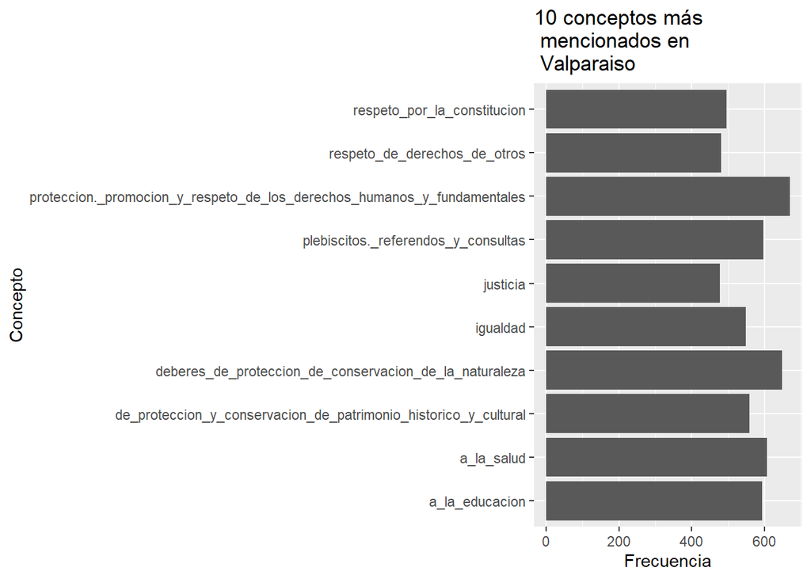

```r
library(ggplot2)  # cargamos la librería

# 10 conceptos más mencionados en Valparaiso
tabla_valparaiso <- data_tf[data_tf$region == 'Valparaiso',]
tabla_valparaiso_sumas = colSums(tabla_valparaiso[,3:114])
tabla_valparaiso_plot = sort(tabla_valparaiso_sumas)
# Ya tenemos un vector que tiene las sumas de todas las columnas

size = length(tabla_valparaiso_plot)
vector_valparaiso = tabla_valparaiso_plot[(size-9):size]
valparaiso <- data.frame(names = names(vector_valparaiso), values = as.numeric(vector_valparaiso))

ggplot(valparaiso) +
  geom_bar(aes(x = names, y = values), stat="identity") +
  coord_flip() +
  ggtitle("10 conceptos más \n mencionados en \n Valparaiso") + # título
  xlab("Concepto") + ylab("Frecuencia")  # etiquetas
```

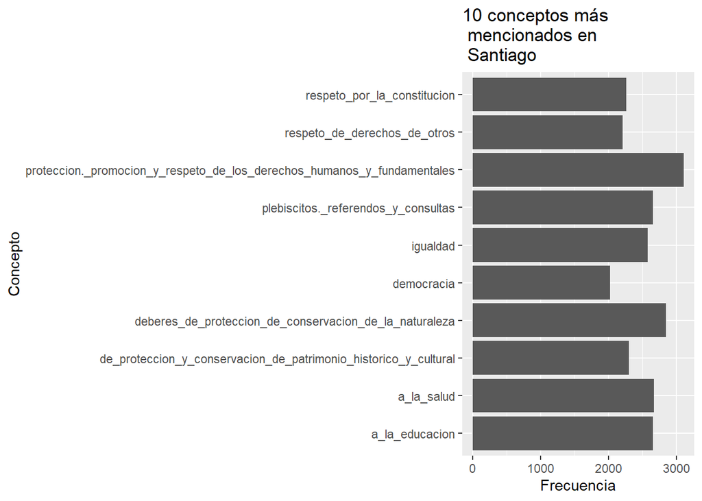

```r
# 10 conceptos más mencionados en Metropolitana de Santiago
tabla_Santiago <- data_tf[data_tf$region == 'Metropolitana de Santiago',]
tabla_Santiago_sumas = colSums(tabla_Santiago[,3:114])
tabla_Santiago_plot = sort(tabla_Santiago_sumas)
# Ya tenemos un vector que tiene las sumas de todas las columnas

size = length(tabla_Santiago_plot)
vector_Santiago = tabla_Santiago_plot[(size-9):size]
Santiago <- data.frame(names = names(vector_Santiago), values = as.numeric(vector_Santiago))

ggplot(Santiago) +
  geom_bar(aes(x = names, y = values), stat="identity") +
  coord_flip() +
  ggtitle("10 conceptos más \n mencionados en \n Santiago") + # título
  xlab("Concepto") + ylab("Frecuencia")  # etiquetas
```

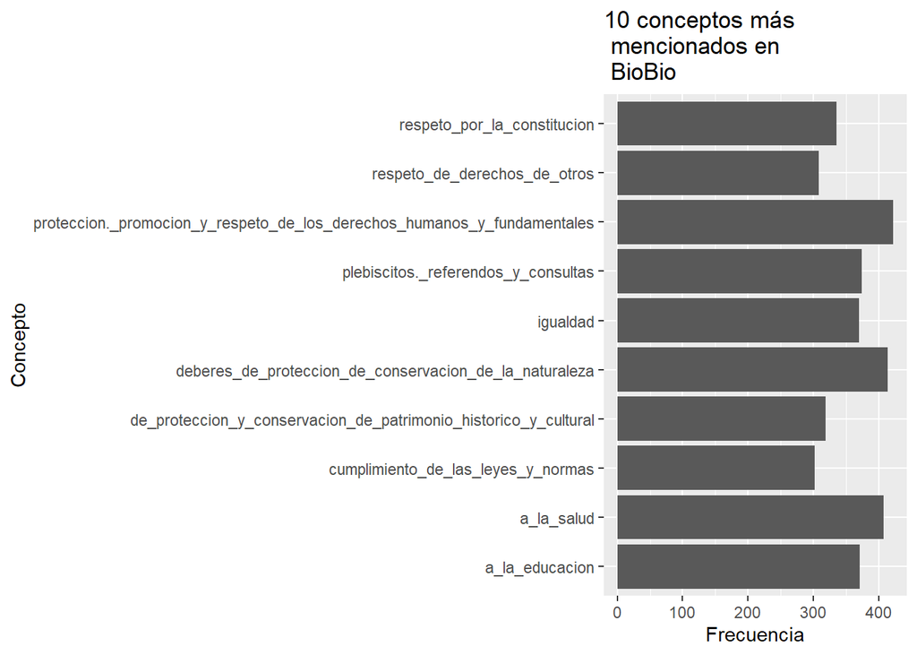

```r
# 10 conceptos más mencionados en Biobio
tabla_Biobio <- data_tf[data_tf$region == 'Biobio',]
tabla_Biobio_sumas = colSums(tabla_Biobio[,3:114])
tabla_Biobio_plot = sort(tabla_Biobio_sumas)
# Ya tenemos un vector que tiene las sumas de todas las columnas

size = length(tabla_Biobio_plot)
vector_Biobio = tabla_Biobio_plot[(size-9):size]
Biobio <- data.frame(names = names(vector_Biobio), values = as.numeric(vector_Biobio))

ggplot(Biobio) +
  geom_bar(aes(x = names, y = values), stat="identity") +
  coord_flip() +
  ggtitle("10 conceptos más \n mencionados en \n BioBio") + # título
  xlab("Concepto") + ylab("Frecuencia")  # etiquetas
```

6. De la pregunta anterior, ¿considera que es razonable usar el conteo de frecuencias para determinar las regiones que tuvieron mayor participación en el proceso? ¿Por qué? Sugiera y solamente comente una forma distinta de hacerlo.

**Respuesta:** No, dado que las regiones de Valparaíso, Biobio y Santiago son las más pobladas en todo el país, por lo que matemáticamente es más probable que tengan mayor participación que el resto de las regiones (Al haber más población, hay más menciones de distintos temas, llevando directamente a mayor participación aparente). Otra forma más razonable de medir la participación sería proporcionalmente, esto es, crear una razón de participación a partir del conteo de frecuencias y la población en las localidades, de esta forma tendremos menciones por cantidad de habitantes.

## 3.3 Ejercicios

### 3.3.1 Accidentes de tránsito

Para esta sección utilizaremos un dataset real de número de accidentes de tránsito por localidad, el cual puede ser encontrado en el siguiente link: http://datos.gob.cl/dataset/9348. Para cargar el dataset ejecute el siguiente código:

```r
tipos <- read.table("https://users.dcc.uchile.cl/~hsarmien/mineria/datasets/accidentes_2010_2011.txt")
head(tipos)
```

```
##    Muestra                   Descripcion Anio TipoAccidente Cantidad
## 1 Nacional                      Nacional 2010     Atropello     8247
## 2 Nacional                      Nacional 2011     Atropello     8339
## 3 Regional XV RegiÃ³n Arica y Parinacota 2010     Atropello      115
## 4 Regional XV RegiÃ³n Arica y Parinacota 2011     Atropello      159
## 5  Comunal                         ARICA 2010     Atropello      115
## 6  Comunal                         ARICA 2011     Atropello      158
```

Explore el set de datos para responder las siguientes preguntas:

1. Filtre los datos para incluir sólo los accidentes ocurridos el año 2010 a nivel regional. Genere un boxplot donde se indique la cantidad de accidentes categorizado por tipo de accidente.

Este tipo de gráfico nos ayudará a entender como se distribuye los datos por cada tipo de accidentes. Es decir, podremos apreciar que tan dispersos o similares son los datos en todo el dataset. También, puede ser útil para observar valores atípicos u outliers en los datos.

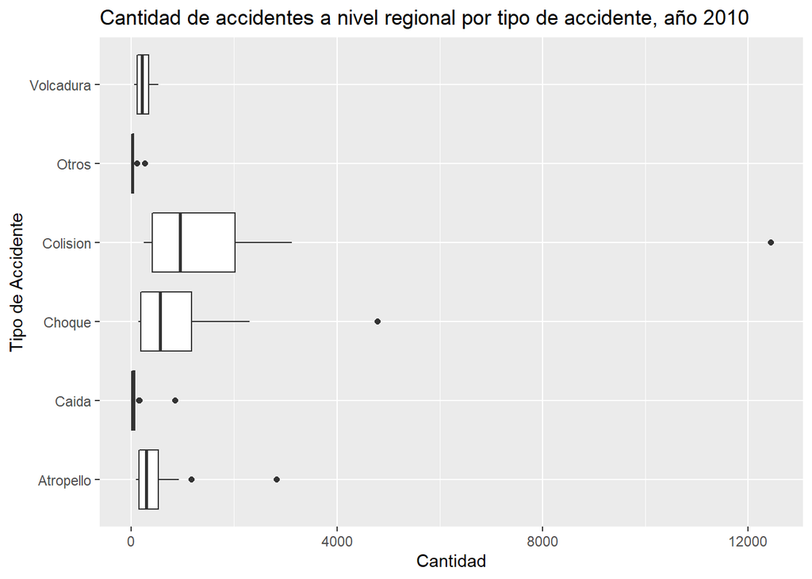

```r
accidentes_regionales_2010 <- with(tipos, tipos[Muestra == "Regional" & Anio == 2010, ])

ggplot(accidentes_regionales_2010, aes(x = TipoAccidente, y = Cantidad)) +
  geom_boxplot() +
  # scale_y_continuous(limits = c(0, 3500)) +   # Línea de código para hacer zoom sobre la muestra. Elimina datos
  coord_flip() +  # transformamos el grafico invirtiendo los ejes de coordenadas (sólo visualmente)
  ggtitle("Cantidad de accidentes a nivel regional por tipo de accidente, año 2010") + # título
  xlab("Tipo de Accidente") + ylab("Cantidad")  # etiquetas +
```

2. ¿Qué otra forma de explorar los datos podría agregar para el dataset de Accidentes de tránsito y qué información adicional aporta? Adjunte una breve explicación.

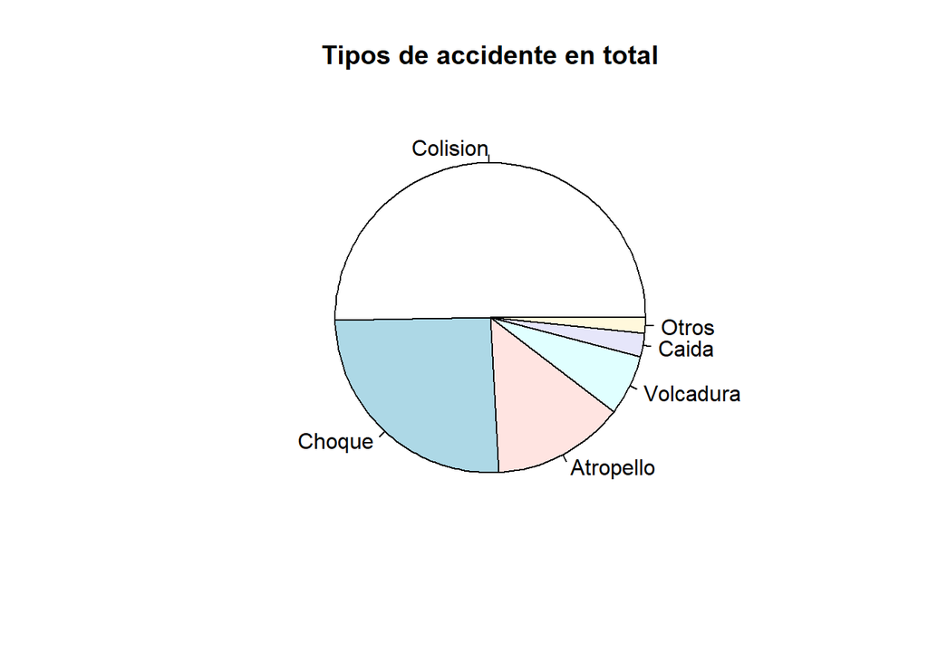

```r
accidentes_nacionales <- with(tipos, tipos[Muestra == "Nacional", ])

porTipo<- tipos %>%
group_by(TipoAccidente) %>%
summarise(total = sum(Cantidad)) %>%
arrange(-total)

pie(porTipo$total, labels=porTipo$TipoAccidente,main="Tipos de accidente en total" )
```

### 3.3.2 Diamantes

Considere el set de datos diamonds del paquete ggplot2 de R, que contiene los precios en dolares, junto con otros atributos importantes: quilates, corte, color y claridad. También hay medidas físicas como ser: x (largo), y (ancho), z (profundidad), depth (porcentaje total de profundidad) y table (ancho desde el tope del diamante al punto relativo más ancho del diamante):

```r
library(ggplot2)
data("diamonds")
head(diamonds)
```

```
## # A tibble: 6 x 10
##   carat cut       color clarity depth table price     x     y     z
##   <dbl> <ord>     <ord> <ord>   <dbl> <dbl> <int> <dbl> <dbl> <dbl>
## 1 0.23  Ideal     E     SI2      61.5    55   326  3.95  3.98  2.43
## 2 0.21  Premium   E     SI1      59.8    61   326  3.89  3.84  2.31
## 3 0.23  Good      E     VS1      56.9    65   327  4.05  4.07  2.31
## 4 0.290 Premium   I     VS2      62.4    58   334  4.2   4.23  2.63
## 5 0.31  Good      J     SI2      63.3    58   335  4.34  4.35  2.75
## 6 0.24  Very Good J     VVS2     62.8    57   336  3.94  3.96  2.48
```

Realice una exploración por el set de datos para responder las siguientes preguntas:

1. Teniendo en cuenta las medidas físicas, ¿considera que existen valores inexistentes o inconsistentes? Describa como manejaría esta situación. Adjunte el código necesario.

```r
sum(is.na(diamonds$depth))
```

```
## [1] 0
```

```r
sum(is.na(diamonds$table))
```

```
## [1] 0
```

```r
sum(is.na(diamonds$x))
```

```
## [1] 0
```

```r
sum(is.na(diamonds$y))
```

```
## [1] 0
```

```r
sum(is.na(diamonds$z))
```

```
## [1] 0
```

```r
summary(diamonds)
```

```
##      carat               cut        color        clarity          depth
##  Min.   :0.2000   Fair     : 1610   D: 6775   SI1    :13065   Min.   :43.00
##  1st Qu.:0.4000   Good     : 4906   E: 9797   VS2    :12258   1st Qu.:61.00
##  Median :0.7000   Very Good:12082   F: 9542   SI2    : 9194   Median :61.80
##  Mean   :0.7979   Premium  :13791   G:11292   VS1    : 8171   Mean   :61.75
##  3rd Qu.:1.0400   Ideal    :21551   H: 8304   VVS2   : 5066   3rd Qu.:62.50
##  Max.   :5.0100                     I: 5422   VVS1   : 3655   Max.   :79.00
##                                     J: 2808   (Other): 2531
##      table           price             x                y
##  Min.   :43.00   Min.   :  326   Min.   : 0.000   Min.   : 0.000
##  1st Qu.:56.00   1st Qu.:  950   1st Qu.: 4.710   1st Qu.: 4.720
##  Median :57.00   Median : 2401   Median : 5.700   Median : 5.710
##  Mean   :57.46   Mean   : 3933   Mean   : 5.731   Mean   : 5.735
##  3rd Qu.:59.00   3rd Qu.: 5324   3rd Qu.: 6.540   3rd Qu.: 6.540
##  Max.   :95.00   Max.   :18823   Max.   :10.740   Max.   :58.900
##
##        z
##  Min.   : 0.000
##  1st Qu.: 2.910
##  Median : 3.530
##  Mean   : 3.539
##  3rd Qu.: 4.040
##  Max.   :31.800
##
```

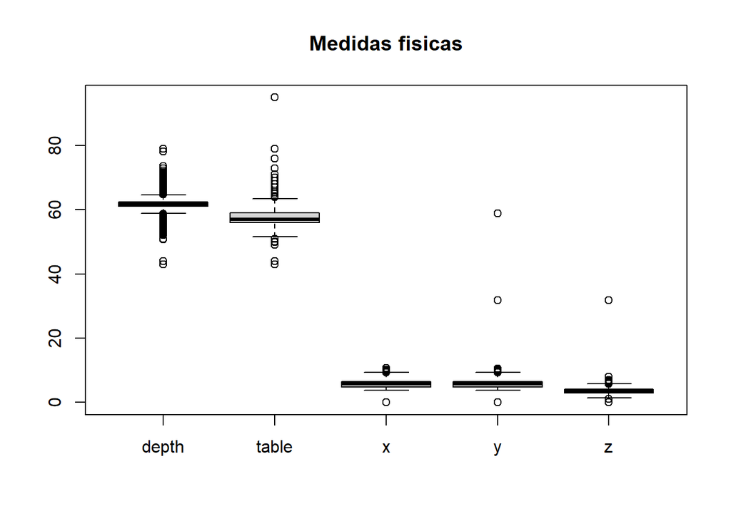

```r
boxplot(x=diamonds[,c("depth","table","x","y","z")], main="Medidas fisicas")
```

**Respuesta:** Respecto a los datos inexistentes poemos contar la cantidad de elementos de tipo NA o Nulo. En este caso, en cada atributo esta suma es 0, indicando que no hay valores Inexistentes. Por otro lado, para detectar datos inconsistentes basta graficar las medidas físicas del dataset usando boxplot y notar los outliers que se generan en cada atributo. Podemos observar que hay una gran cantidad de datos atípicos en Profundidad y Table.

2. Considerando la relación entre dos atributos, ¿cuál es la correlación más alta para table? y ¿qué atributos están más correlacionadas con precio (price) y qué significa esto? Adjunte el código necesario para la respuesta.

```r
cor(diamonds[,c("carat","price","depth","table","x","y","z")])
```

```
##            carat      price       depth      table           x           y
## carat 1.00000000  0.9215913  0.02822431  0.1816175  0.97509423  0.95172220
## price 0.92159130  1.0000000 -0.01064740  0.1271339  0.88443516  0.86542090
## depth 0.02822431 -0.0106474  1.00000000 -0.2957785 -0.02528925 -0.02934067
## table 0.18161755  0.1271339 -0.29577852  1.0000000  0.19534428  0.18376015
## x     0.97509423  0.8844352 -0.02528925  0.1953443  1.00000000  0.97470148
## y     0.95172220  0.8654209 -0.02934067  0.1837601  0.97470148  1.00000000
## z     0.95338738  0.8612494  0.09492388  0.1509287  0.97077180  0.95200572
##                z
## carat 0.95338738
## price 0.86124944
## depth 0.09492388
## table 0.15092869
## x     0.97077180
## y     0.95200572
## z     1.00000000
```

3. Proponga otra forma para explorar los datos. ¿Qué información adicional aporta? Adjunte una breve explicación.

**Respuesta:** Otra forma para explorar los datos sería convertir el atributo corte en alguna medida numérica. Dado que el atributo actualmente es de tipo orden y string, y no es posible ver alguna relación entre le precio y tamaño con el tipo de corte (bueno, muy bueno, premium, etc.) que intuitivamente podrían estar corelacionados.